Luis Antonio Ortega Andrés  
Antonio Coín Castro

# Kernel PCA

Adapted by alberto.suarez@uam.es from

[Kernel PCA (sklearn)](https://scikit-learn.org/stable/auto_examples/decomposition/plot_kernel_pca.html#sphx-glr-auto-examples-decomposition-plot-kernel-pca-py)  
Authors: Mathieu Blondel, Andreas Mueller

License: [BSD 3 clause](https://opensource.org/licenses/BSD-3-Clause)

```python
import numpy as np
import matplotlib.pyplot as plt
from IPython.display import HTML

from sklearn import datasets
from sklearn.decomposition import PCA, KernelPCA

import kernel_machine_learning as kpca

%load_ext autoreload
%autoreload 2

seed = 0
np.random.seed(seed)  # for reproducible results
```

## PCA, KPCA and comparison with Sklearn

```python
# Input data
X, y = datasets.make_moons(n_samples=400,
                           noise=.05,
                           random_state=seed)
```

```python
# Principal componets

# PCA (linear)
X_pca, eigenvals_pca, eigenvecs_pca = \
    kpca.kernel_pca(X, X, kpca.linear_kernel)

# Kernel PCA
A = 1.0
gamma = 20.0
L = np.sqrt(0.5/gamma)

def rbf_kernel(X, X_prime):
    return kpca.rbf_kernel(X, X_prime, A, L)


X_kpca, eigenvals_kpca, eigenvecs_kpca = \
    kpca.kernel_pca(X, X, rbf_kernel)

# PCA (sklearn)
pca = PCA()
X_pca_sk = pca.fit_transform(X)

# Kernel PCA (sklearn)
kernel_pca = KernelPCA(kernel='rbf',
                       fit_inverse_transform=True,
                       gamma=gamma)
X_kpca_sk = kernel_pca.fit_transform(X)
X_back = kernel_pca.inverse_transform(X_kpca_sk)
```

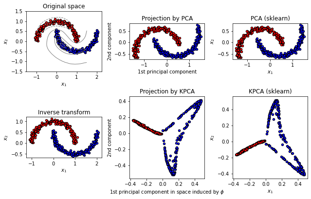

```python
# Plot results

plt.figure(figsize=(9, 6))
plt.subplot(2, 3, 1, aspect='equal')
plt.title('Original space')
reds = y == 0
blues = y == 1

# Original dataset
plt.scatter(X[reds, 0], X[reds, 1], c='red',
            s=20, edgecolor='k')
plt.scatter(X[blues, 0], X[blues, 1], c='blue',
            s=20, edgecolor='k')
plt.xlabel('$x_1$')
plt.ylabel('$x_2$')

# Projection on the first principal component (in the phi space)
X1, X2 = np.meshgrid(np.linspace(-1.5, 1.5, 50),
                     np.linspace(-1.5, 1.5, 50))
X_grid = np.array([np.ravel(X1), np.ravel(X2)]).T
Z_grid = kernel_pca.transform(X_grid)[:, 0].reshape(X1.shape)
plt.contour(X1, X2, Z_grid, colors='grey', linewidths=1, origin='lower')

# Inverse transform
plt.subplot(2, 3, 4, aspect='equal')
plt.scatter(X_back[reds, 0], X_back[reds, 1], c="red",
            s=20, edgecolor='k')
plt.scatter(X_back[blues, 0], X_back[blues, 1], c="blue",
            s=20, edgecolor='k')
plt.title("Inverse transform")
plt.xlabel("$x_1$")
plt.ylabel("$x_2$")

# PCA and KPCA projections
plt.subplot(2, 3, 2, aspect='equal')
plt.scatter(X_pca[reds, 0], X_pca[reds, 1], c="red",
            s=20, edgecolor='k')
plt.scatter(X_pca[blues, 0], X_pca[blues, 1], c="blue",
            s=20, edgecolor='k')
plt.title("Projection by PCA")
plt.xlabel("1st principal component")
plt.ylabel("2nd component")

plt.subplot(2, 3, 5, aspect='equal')
plt.scatter(X_kpca[reds, 0], X_kpca[reds, 1], c="red",
            s=20, edgecolor='k')
plt.scatter(X_kpca[blues, 0], X_kpca[blues, 1], c="blue",
            s=20, edgecolor='k')
plt.title("Projection by KPCA")
plt.xlabel(r"1st principal component in space induced by $\phi$")
plt.ylabel("2nd component")

plt.subplot(2, 3, 3, aspect='equal')
plt.scatter(X_pca_sk[reds, 0], X_pca_sk[reds, 1], c="red",
            s=20, edgecolor='k')
plt.scatter(X_pca_sk[blues, 0], X_pca_sk[blues, 1], c="blue",
            s=20, edgecolor='k')
plt.title("PCA (sklearn)")
plt.xlabel("$x_1$")
plt.ylabel("$x_2$")

plt.subplot(2, 3, 6, aspect='equal')
plt.scatter(X_kpca_sk[reds, 0], X_kpca_sk[reds, 1], c="red",
            s=20, edgecolor='k')
plt.scatter(X_kpca_sk[blues, 0], X_kpca_sk[blues, 1], c="blue",
            s=20, edgecolor='k')
plt.title("KPCA (sklearn)")
plt.xlabel("$x_1$")
plt.ylabel("$x_2$")

plt.tight_layout()
plt.show()
```

## KPCA animation

We make an animation that shows the evolution of the projections onto the first two KPCA components for $0.002\leq\gamma\leq 20000.0$.

```python
animation = kpca.AnimationKPCA(n_frames=100,
                               xlims=(-1, 1),
                               ylims=(-1, 1)).animate(X, X, y)
plt.close()
HTML(animation.to_jshtml())
```

[figure not shown]

## Questions

Both representations are correct and valid; what makes them different is the decision made when normalizing the eigenvectors. The eigenvectors returned via specialized functions such as `eig` and `eigh` (for symmetric cases) are normalized in $\mathbb{R}^N$, that is, they verify $\|\alpha_i \|_{\mathcal{L}_2} = 1$. However, what we really want is that the eigenvectors induced by these $\alpha_i$ be normalized in the subjacent Hilbert space. As we saw in the class lectures, this can be achieved by ensuring that their $\mathcal{L}_2$-norm in $\mathbb{R}^N$ equals the inverse of the square root of their corresponding eigenvalues, $1/\sqrt{\lambda_i}$. Since the $\alpha_i$ are unitary, the procedure is simply to divide each eigenvector by this quantity. It is in this step that the discrepancy arises, as one may divide by $-1/\sqrt{\lambda_i}$ and still get the same $\mathcal{L}_2$-norm.

Sklearn's implementation uses an auxiliary function `svd_flip` that deterministically assigns a sign for each normalized eigenvector (see [Sklearn's source code](https://github.com/scikit-learn/scikit-learn/blob/15c2c72e27c6ea18566f4e786506c7a3aef8a5de/sklearn/utils/extmath.py#L504}{reference)). We have implemented this option as a parameter for our function in order to reproduce Sklearn's output perfectly.

In our case, not using this function leads to a reflection of the second principal component in the Kernel PCA graph with respect to Sklearn's (all values of this vector are multiplied by $-1$). There is nothing special about the second principal component, only that the corresponding eigenvector had the sign flipped. Linear PCA does not show discrepancies by pure coincidence.

1. *What is the behavior in the limit in which the width of the kernel approaches $\infty$?. Explain why one should expect such behavior.*
2. *What is the behavior in the limit in which the width of the kernel approaches $0$?. Explain why one should expect such behavior.*

$$ \lim_{\gamma \to \infty} = \lim_{\sigma \to 0^{+}} \mathcal{K}(x,y) = 0. $$

Let us begin by analyzing the first limit. In this case, if $x=y$ we have $\mathcal K(x,y)=A=1$ as well, so all in all we have: $$ \lim_{\gamma\to0^+} \mathcal K( X, X) = 1, $$ where $ 1$ is a matrix with the same dimension as $K\equiv \mathcal K( X, X)$ containing all ones. Now observe that when we center this kernel, the expression in the limit is: $$ \hat K = 1 - (2/N) 1 1 + (1/N^2) 1 1 1 = 0, $$ that is, we get the null matrix. As a result, the limit case of the projection reduces to the matrix operation $$ 0 \begin{pmatrix}e_{1} & \dots e_{N} \end{pmatrix} = 0, $$ where $e_{1}, \dots, e_{N}$ are the computed eigenvectors of a null matrix, i.e, any orthonormal basis in $\mathbb R^N$. When $\hat K$ is not entirely a null matrix but it is close to it, redoing the above calculations we may approximate it as $$ \hat{K} = \varepsilon \boldsymbol{1}, \quad \varepsilon << 1, $$ where $\boldsymbol{1}$ is a matrix with all ones. It is immediate to see that the normalized eigenvectors of such a matrix are the same for each value of $\varepsilon$, and as a result, the matrix multiplication consists of scaling via $\varepsilon$ the desired projection: $$ \hat{K} \begin{pmatrix}e_{1} & \dots e_{N} \end{pmatrix} = \varepsilon \boldsymbol{1} \begin{pmatrix}e_{1} & \dots e_{N} \end{pmatrix}, $$

but the basis of eigenvectors $\{e_1, \dots, e_N\}$ is the same as the one obtained when $\varepsilon$ is larger (but still within the bounds of our approximation). This behaviour can be seen in the animation above (or in the example below), where as $\gamma \to 0$ (i.e, $\varepsilon \to 0$), the projection structure is preserved, but reduced in scale.

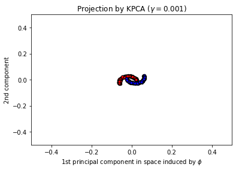

```python
gamma = 1e-3
L = np.sqrt(0.5/gamma)

def rbf_kernel(X, X_prime):
    return kpca.rbf_kernel(X, X_prime, A, L)


X_kpca, _, _ = kpca.kernel_pca(X, X, rbf_kernel)

plt.scatter(X_kpca[reds, 0], X_kpca[reds, 1], c="red",
            s=20, edgecolor='k')
plt.scatter(X_kpca[blues, 0], X_kpca[blues, 1], c="blue",
            s=20, edgecolor='k')
plt.title(r"Projection by KPCA ($\gamma=$" + f"{gamma})")
plt.xlabel(r"1st principal component in space induced by $\phi$")
plt.ylabel("2nd component")
plt.xlim((-0.5, 0.5))
plt.ylim((-0.5, 0.5))
plt.show()
```

Next we consider the second case, where the kernel tends to $ 0 $ on any pair of non equal points. This does not apply when computing $\lim_{\gamma \to \infty} \mathcal{K}(x,x)$, as $\mathcal{K}(x,x) = 1$ is constant for any given value of $\gamma$. Considering this, the kernel matrix converges to $$ \lim_{\gamma \to \infty} \mathcal{K}({X}, {X}) = {I}, $$ where ${I}$ is the identity matrix of order $N$. In this case, centering the kernel amounts to a small perturbation of $1/N$, so it can be ignored for our purposes. The situation in this case is this: the application of the kernel to any set of points results in an identity matrix, which has all of its eigenvalues equal to $ 1 $, and its eigenvector can be any orthonormal basis in $\mathbb{R}^N$. There is no need for such base to be the usual basis of $\mathbb{R}^N$, but it is the case when using Numpy's `eigh` function.

As a result, the kernel method performs the following matrix operation in the limit: $$ \mathcal{K}({X}, {X})\begin{pmatrix} e_1 & \dots & e_N \end{pmatrix} = {I}{I} = {I}. $$

Given this, plotting a projection over the first two principal components leads to the degenerate case of projecting a point in $ (1,0) $ and another point in $ (0,1) $, while the rest are mapped to the origin. This phenomenon can approximately be seen if we set a large enough value of $\gamma$:

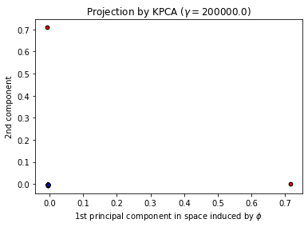

```python
gamma = 2e5
L = np.sqrt(0.5/gamma)

def rbf_kernel(X, X_prime):
    return kpca.rbf_kernel(X, X_prime, A, L)


X_kpca, _, _ = kpca.kernel_pca(X, X, rbf_kernel)

plt.scatter(X_kpca[reds, 0], X_kpca[reds, 1], c="red",
            s=20, edgecolor='k')
plt.scatter(X_kpca[blues, 0], X_kpca[blues, 1], c="blue",
            s=20, edgecolor='k')
plt.title(r"Projection by KPCA ($\gamma=$" + f"{gamma})")
plt.xlabel(r"1st principal component in space induced by $\phi$")
plt.ylabel("2nd component")
plt.show()
```

However, there is an interesting behaviour of the `eigh` function when its argument is almost an identity matrix, but not exactly (that is, when $\gamma$ is big but not that big). The returned eigenvalues are roughly equal to $1$ and the eigenvectors are nearly an orthonormal basis of $\mathbb{R}^N$, but they are not close to being the usual base. As a result, the plot leads to the projection over $\mathbb{R}^2$ of a basis in $\mathbb{R}^N$, which corresponds to the "spiked" appearance of the projection, in which the lines that are formed seem to be the projection of perpendicular axes from a higher dimensional space.

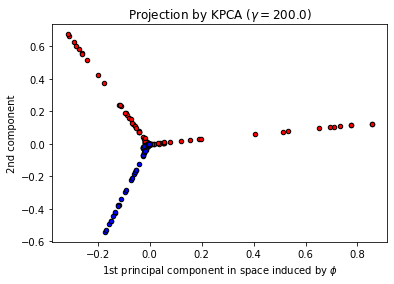

```python
gamma = 2e2
L = np.sqrt(0.5/gamma)

def rbf_kernel(X, X_prime):
    return kpca.rbf_kernel(X, X_prime, A, L)


X_kpca, eigenvals_kpca, eigenvecs_kpca = \
    kpca.kernel_pca(X, X, rbf_kernel)

plt.scatter(X_kpca[reds, 0], X_kpca[reds, 1], c="red",
            s=20, edgecolor='k')
plt.scatter(X_kpca[blues, 0], X_kpca[blues, 1], c="blue",
            s=20, edgecolor='k')
plt.title(r"Projection by KPCA ($\gamma=$" + f"{gamma})")
plt.xlabel(r"1st principal component in space induced by $\phi$")
plt.ylabel("2nd component")
plt.show()
```